# Practical Machine Learning course Project

Bernard Lei

June 1, 2016

## Introduction

Using Jawbone Up, Nike FuelBand, and Fitbit, one can collect a large amount of data about personal activity relatively inexpensively. These type of devices are part of the quantified self movement - a group of enthusiasts who take measurements about themselves regularly to improve their health, to find patterns in their behavior, or because they are tech geeks. One thing that people regularly do is quantify how much of a particular activity they do, but they rarely quantify how well they do it. In this project, the goal will be to use data from accelerometers on the belt, forearm, arm, and dumbell of 6 participants. They were asked to perform barbell lifts correctly and incorrectly in 5 different ways. For more information, go to this website here: http://groupware.les.inf.puc-rio.br/har (see the section on the Weight Lifting Exercise Dataset).

## Synopsis

Using the training data and test data available from online to predict the test data output, based on the training data. The training data are available here: https://d396qusza40orc.cloudfront.net/predmachlearn/pml-training.csv The test data are available here: https://d396qusza40orc.cloudfront.net/predmachlearn/pml-testing.csv The data for this project come from this source: http://groupware.les.inf.puc-rio.br/har. The main objective to find the best prediction method in R for classification output, using data from accelerometers on the belt, forearm, arm, and dumbell of 6 participants.

## Actual class specification

Six young health participants were asked to perform one set of 10 repetitions of the Unilateral Dumbbell Biceps Curl in five different fashions: exactly according to the specification (Class A), throwing the elbows to the front (Class B), lifting the dumbbell only halfway (Class C), lowering the dumbbell only halfway (Class D) and throwing the hips to the front (Class E).

## Increase the size of the memory allocation

```r
memory.limit()
```

```
## [1] 2936
```

```r
memory.limit(size=9000)
```

```
## [1] 9000
```

## Load libraries

```r
library(caret)
library(rattle)
library(gridExtra)
library(e1071)
library(kknn)
```

```r
library(nnet)
library(rpart)
library(rpart.plot)
```

## Load the data sets

```r
pmltestdata <- read.csv("pml-testing.csv")
pmltraindata <- read.csv("pml-training.csv")
colnames(pmltestdata)
```

```
##   [1] "X"                        "user_name"
##   [3] "raw_timestamp_part_1"     "raw_timestamp_part_2"
##   [5] "cvtd_timestamp"           "new_window"
##   [7] "num_window"               "roll_belt"
##   [9] "pitch_belt"               "yaw_belt"
##  [11] "total_accel_belt"         "kurtosis_roll_belt"
##  [13] "kurtosis_picth_belt"      "kurtosis_yaw_belt"
##  [15] "skewness_roll_belt"       "skewness_roll_belt.1"
##  [17] "skewness_yaw_belt"        "max_roll_belt"
##  [19] "max_picth_belt"           "max_yaw_belt"
##  [21] "min_roll_belt"            "min_pitch_belt"
##  [23] "min_yaw_belt"             "amplitude_roll_belt"
##  [25] "amplitude_pitch_belt"     "amplitude_yaw_belt"
##  [27] "var_total_accel_belt"     "avg_roll_belt"
##  [29] "stddev_roll_belt"         "var_roll_belt"
```

[output cut: 65 more lines]

```r
colnames(pmltestdata)[colSums(is.na(pmltestdata)) > 0]
```

```
##   [1] "kurtosis_roll_belt"       "kurtosis_picth_belt"
##   [3] "kurtosis_yaw_belt"        "skewness_roll_belt"
##   [5] "skewness_roll_belt.1"     "skewness_yaw_belt"
##   [7] "max_roll_belt"            "max_picth_belt"
##   [9] "max_yaw_belt"             "min_roll_belt"
##  [11] "min_pitch_belt"           "min_yaw_belt"
##  [13] "amplitude_roll_belt"      "amplitude_pitch_belt"
##  [15] "amplitude_yaw_belt"       "var_total_accel_belt"
##  [17] "avg_roll_belt"            "stddev_roll_belt"
##  [19] "var_roll_belt"            "avg_pitch_belt"
##  [21] "stddev_pitch_belt"        "var_pitch_belt"
##  [23] "avg_yaw_belt"             "stddev_yaw_belt"
##  [25] "var_yaw_belt"             "var_accel_arm"
##  [27] "avg_roll_arm"             "stddev_roll_arm"
##  [29] "var_roll_arm"             "avg_pitch_arm"
```

[output cut: 35 more lines]

```r
colnames(pmltraindata)[colSums(is.na(pmltraindata)) > 0]
```

```
##  [1] "max_roll_belt"            "max_picth_belt"
##  [3] "min_roll_belt"            "min_pitch_belt"
##  [5] "amplitude_roll_belt"      "amplitude_pitch_belt"
##  [7] "var_total_accel_belt"     "avg_roll_belt"
##  [9] "stddev_roll_belt"         "var_roll_belt"
## [11] "avg_pitch_belt"           "stddev_pitch_belt"
## [13] "var_pitch_belt"           "avg_yaw_belt"
## [15] "stddev_yaw_belt"          "var_yaw_belt"
## [17] "var_accel_arm"            "avg_roll_arm"
## [19] "stddev_roll_arm"          "var_roll_arm"
## [21] "avg_pitch_arm"            "stddev_pitch_arm"
## [23] "var_pitch_arm"            "avg_yaw_arm"
## [25] "stddev_yaw_arm"           "var_yaw_arm"
## [27] "max_roll_arm"             "max_picth_arm"
## [29] "max_yaw_arm"              "min_roll_arm"
```

[output cut: 19 more lines]

## Clean up the training data

## search for column name beginning with “roll”

```r
traindata_roll <- grepl("^roll", colnames(pmltraindata))
rolldata <- pmltraindata[, traindata_roll]
```

## search for column name beginning with “pitch”

```r
traindata_pitch <- grepl("^pitch", colnames(pmltraindata))
pitchdata <- pmltraindata[, traindata_pitch]
```

## search for column name beginning with “yaw”

```r
traindata_yaw <- grepl("^yaw", colnames(pmltraindata))
yawdata <- pmltraindata[, traindata_yaw]
```

## search for column name beginning with “total”

```r
traindata_total <- grepl("^total", colnames(pmltraindata))
totaldata <- pmltraindata[, traindata_total]
```

## search for column name beginning with “gyros”

```r
traindata_gyros <- grepl("^gyros", colnames(pmltraindata))
gyrosdata <- pmltraindata[, traindata_gyros]
```

## search for column name beginning with “accel”

```r
traindata_accel <- grepl("^accel", colnames(pmltraindata))
acceldata <- pmltraindata[, traindata_accel]
```

## search for column name beginning with “magnet”

```r
traindata_magnet <- grepl("^magnet", colnames(pmltraindata))
magnetdata <- pmltraindata[, traindata_magnet]
```

## search for column name beginning with “classe”

```r
traindata_classe <- grepl("^classe", colnames(pmltraindata))
classedata <- pmltraindata[, traindata_classe]
```

## combine all the columns together

```r
traindata <- cbind(rolldata, pitchdata, yawdata, totaldata, gyrosdata, acceldata, magnetdata, classedata)
```

## search for column name beginning with “roll”

```r
testdata_roll <- grepl("^roll", colnames(pmltestdata))
rolltdata <- pmltestdata[, testdata_roll]
```

## search for column name beginning with “pitch”

```r
testdata_pitch <- grepl("^pitch", colnames(pmltestdata))
pitchtdata <- pmltestdata[, testdata_pitch]
```

## search for column name beginning with “yaw”

```r
testdata_yaw <- grepl("^yaw", colnames(pmltestdata))
yawtdata <- pmltestdata[, testdata_yaw]
```

## search for column name beginning with “total”

```r
testdata_total <- grepl("^total", colnames(pmltestdata))
totaltdata <- pmltestdata[, testdata_total]
```

## search for column name beginning with “gyros”

```r
testdata_gyros <- grepl("^gyros", colnames(pmltestdata))
gyrostdata <- pmltestdata[, testdata_gyros]
```

## search for column name beginning with “accel”

```r
testdata_accel <- grepl("^accel", colnames(pmltestdata))
acceltdata <- pmltestdata[, testdata_accel]
```

## search for column name beginning with “magnet”

```r
testdata_magnet <- grepl("^magnet", colnames(pmltestdata))
magnettdata <- pmltestdata[, testdata_magnet]
```

## search for column name beginning with “problem”

```r
testdata_problem <- grepl("^problem", colnames(pmltestdata))
problemtdata <- pmltestdata[, testdata_problem]
```

## combine all the columns together

```r
testdata <- cbind(rolltdata, pitchtdata, yawtdata, totaltdata, gyrostdata, acceltdata, magnettdata, problemtdata)
```

## Visualize the data

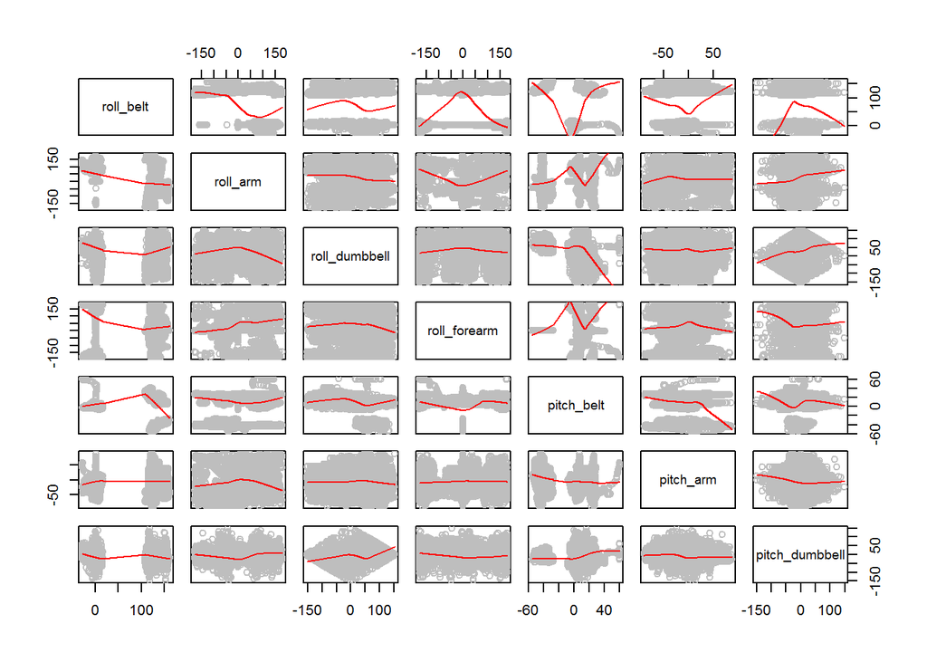

## Analysis:

The data are not linear to the output labels at all, must use non-linear classification prediction methods.

## Training subset data(training and cross validation purpose)

Training subset data for training and cross validation 60% of the training subset data for training purpose and 40% for cross validation purpose.

```r
set.seed(333)
inTrain = createDataPartition(traindata$classedata, p = .60)[[1]]
trainingsubset = traindata[ inTrain,]
testingsubset = traindata[-inTrain,]
dim(trainingsubset)
```

```
## [1] 11776    53
```

```r
dim(testingsubset)
```

```
## [1] 7846   53
```

```r
dim(traindata)
```

```
## [1] 19622    53
```

## 1st method: random forest

```r
modelFit <- train(classedata ~ ., data=trainingsubset, method="rf", trControl=trainControl(method = "cv", number = 4), prox=TRUE)
print(modelFit)
```

```
## Random Forest
##
## 11776 samples
##    52 predictor
##     5 classes: 'A', 'B', 'C', 'D', 'E'
##
## No pre-processing
## Resampling: Cross-Validated (4 fold)
## Summary of sample sizes: 8831, 8833, 8833, 8831
## Resampling results across tuning parameters:
##
##   mtry  Accuracy   Kappa      Accuracy SD   Kappa SD
##    2    0.9866679  0.9831316  0.0007499153  0.0009492367
##   27    0.9881120  0.9849599  0.0021261279  0.0026900861
##   52    0.9806396  0.9755019  0.0043001483  0.0054438795
##
## Accuracy was used to select the optimal model using  the largest value.
## The final value used for the model was mtry = 27.
```

```r
varImp(modelFit)
```

```
## rf variable importance
##
##   only 20 most important variables shown (out of 52)
##
##                      Overall
## roll_belt             100.00
## pitch_forearm          61.89
## yaw_belt               52.97
## magnet_dumbbell_z      44.43
## pitch_belt             43.06
## magnet_dumbbell_y      41.17
## roll_forearm           40.87
## accel_dumbbell_y       22.65
## magnet_dumbbell_x      20.09
## roll_dumbbell          19.79
## accel_forearm_x        16.68
## magnet_belt_z          15.40
## accel_dumbbell_z       14.08
## magnet_belt_y          13.72
## magnet_forearm_z       13.41
## total_accel_dumbbell   13.06
## accel_belt_z           12.04
## gyros_belt_z           11.73
## yaw_arm                10.20
## magnet_belt_x           9.71
```

```r
outputpredict=predict(modelFit,testingsubset)
head(outputpredict)
```

```
## [1] A A A A A A
## Levels: A B C D E
```

```r
tail(outputpredict)
```

```
## [1] E E E E E E
## Levels: A B C D E
```

## Confusion matrix

```r
confusionMatrix(testingsubset$classedata,outputpredict)
```

```
## Confusion Matrix and Statistics
##
##           Reference
## Prediction    A    B    C    D    E
##          A 2228    3    1    0    0
##          B   15 1498    4    1    0
##          C    0   13 1352    3    0
##          D    0    0   12 1274    0
##          E    0    0    0    8 1434
##
## Overall Statistics
##
##                Accuracy : 0.9924
##                  95% CI : (0.9902, 0.9942)
##     No Information Rate : 0.2859
##     P-Value [Acc > NIR] : < 2.2e-16
##
##                   Kappa : 0.9903
##  Mcnemar's Test P-Value : NA
##
## Statistics by Class:
##
##                      Class: A Class: B Class: C Class: D Class: E
## Sensitivity            0.9933   0.9894   0.9876   0.9907   1.0000
## Specificity            0.9993   0.9968   0.9975   0.9982   0.9988
## Pos Pred Value         0.9982   0.9868   0.9883   0.9907   0.9945
## Neg Pred Value         0.9973   0.9975   0.9974   0.9982   1.0000
## Prevalence             0.2859   0.1930   0.1745   0.1639   0.1828
## Detection Rate         0.2840   0.1909   0.1723   0.1624   0.1828
## Detection Prevalence   0.2845   0.1935   0.1744   0.1639   0.1838
## Balanced Accuracy      0.9963   0.9931   0.9926   0.9944   0.9994
```

```r
cm1 <- confusionMatrix(testingsubset$classedata,outputpredict)
cm1$overall['Accuracy']
```

```
##  Accuracy
## 0.9923528
```

## 2nd model: decision tree(rpart)

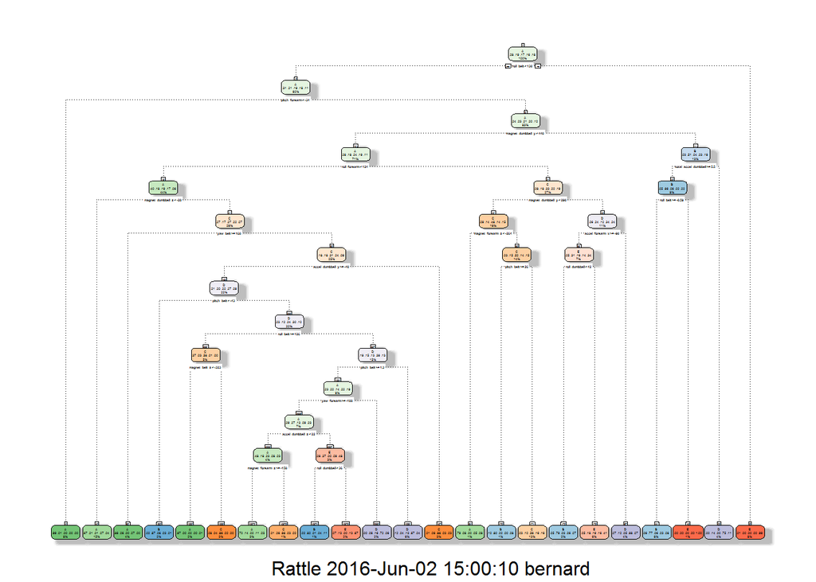

```r
modelFit2 <- rpart(classedata ~ ., method="class", data=trainingsubset)
fancyRpartPlot(modelFit2)
```

```r
outputpredict2 <- predict(modelFit2, testingsubset, type = "class")
confusionMatrix(testingsubset$classedata,outputpredict2)
```

```
## Confusion Matrix and Statistics
##
##           Reference
## Prediction    A    B    C    D    E
##          A 2010   50   63   77   32
##          B  333  811  145  124  105
##          C   22   66 1119   82   79
##          D  149   31  213  799   94
##          E   46   94  163   81 1058
##
## Overall Statistics
##
##                Accuracy : 0.7388
##                  95% CI : (0.729, 0.7485)
##     No Information Rate : 0.3263
##     P-Value [Acc > NIR] : < 2.2e-16
##
##                   Kappa : 0.6682
##  Mcnemar's Test P-Value : < 2.2e-16
##
## Statistics by Class:
##
##                      Class: A Class: B Class: C Class: D Class: E
## Sensitivity            0.7852   0.7709   0.6571   0.6870   0.7734
## Specificity            0.9580   0.8959   0.9595   0.9271   0.9407
## Pos Pred Value         0.9005   0.5343   0.8180   0.6213   0.7337
## Neg Pred Value         0.9020   0.9619   0.9098   0.9445   0.9516
## Prevalence             0.3263   0.1341   0.2171   0.1482   0.1744
## Detection Rate         0.2562   0.1034   0.1426   0.1018   0.1348
## Detection Prevalence   0.2845   0.1935   0.1744   0.1639   0.1838
## Balanced Accuracy      0.8716   0.8334   0.8083   0.8071   0.8571
```

```r
cm2 <- confusionMatrix(testingsubset$classedata,outputpredict2)
cm2$overall['Accuracy']
```

```
##  Accuracy
## 0.7388478
```

## 3rd method: naive bayes

```r
modelFit3<-naiveBayes(classedata~.,data=trainingsubset)
print(modelFit3)
```

```
##
## Naive Bayes Classifier for Discrete Predictors
##
## Call:
## naiveBayes.default(x = X, y = Y, laplace = laplace)
##
## A-priori probabilities:
## Y
##         A         B         C         D         E
## 0.2843071 0.1935292 0.1744226 0.1638927 0.1838485
##
## Conditional probabilities:
##    roll_belt
## Y       [,1]     [,2]
##   A 58.22224 60.18574
##   B 64.10447 60.08201
##   C 64.02526 61.04565
##   D 60.73237 61.52460
##   E 73.83547 70.62181
##
##    roll_arm
## Y         [,1]     [,2]
##   A  0.3978614 84.78880
##   B 34.3560641 72.15823
##   C 24.7724148 57.02029
##   D 22.2648912 56.15549
##   E 21.2153487 75.01059
##
##    roll_dumbbell
## Y        [,1]     [,2]
##   A  21.81195 59.64244
##   B  35.09745 73.26474
##   C -13.04965 76.47032
##   D  51.71259 51.82030
##   E  26.07519 74.49334
##
##    roll_forearm
## Y       [,1]      [,2]
##   A 26.98550  77.33065
##   B 32.57323 114.40852
```

[output cut: 372 more lines]

```
##    magnet_forearm_y
## Y       [,1]     [,2]
##   A 484.6221 422.4887
##   B 288.4032 582.7344
##   C 495.5594 419.7900
##   D 315.4083 491.8326
##   E 272.3206 576.6855
##
##    magnet_forearm_z
## Y       [,1]     [,2]
##   A 408.3476 356.4203
##   B 372.4989 404.2681
##   C 467.0136 340.5540
##   D 366.6782 347.9588
##   E 352.2762 383.7231
```

```r
outputpredict3=predict(modelFit3,testingsubset)
confusionMatrix(testingsubset$classedata,outputpredict3)
```

```
## Confusion Matrix and Statistics
##
##           Reference
## Prediction    A    B    C    D    E
##          A  565  219 1097  290   61
##          B   43  909  346  111  109
##          C   18  156  981  151   62
##          D    0   41  465  611  169
##          E   15  323  212  195  697
##
## Overall Statistics
##
##                Accuracy : 0.4796
##                  95% CI : (0.4685, 0.4907)
##     No Information Rate : 0.3952
##     P-Value [Acc > NIR] : < 2.2e-16
##
##                   Kappa : 0.36
##  Mcnemar's Test P-Value : < 2.2e-16
##
## Statistics by Class:
##
##                      Class: A Class: B Class: C Class: D Class: E
## Sensitivity           0.88144   0.5516   0.3163  0.44993  0.63479
## Specificity           0.76863   0.9017   0.9184  0.89596  0.88960
## Pos Pred Value        0.25314   0.5988   0.7171  0.47512  0.48336
## Neg Pred Value        0.98646   0.8832   0.6727  0.88613  0.93738
## Prevalence            0.08170   0.2100   0.3952  0.17308  0.13994
## Detection Rate        0.07201   0.1159   0.1250  0.07787  0.08884
## Detection Prevalence  0.28448   0.1935   0.1744  0.16391  0.18379
## Balanced Accuracy     0.82503   0.7267   0.6174  0.67294  0.76219
```

```r
cm3 <- confusionMatrix(testingsubset$classedata,outputpredict3)
cm3$overall['Accuracy']
```

```
##  Accuracy
## 0.4796074
```

## 4th method: Nearest Neighbor

```r
training_kknn <- kknn(classedata ~ ., trainingsubset, testingsubset, distance = 1, kernel = "triangular")

outputpredict4 <- fitted(training_kknn)
```

## confustion matrix

```r
table(testingsubset$classedata, outputpredict4)
```

```
##    outputpredict4
##        A    B    C    D    E
##   A 2226    3    2    1    0
##   B   19 1484   13    2    0
##   C    1   13 1349    3    2
##   D    0    0   25 1258    3
##   E    0    0    0    3 1439
```

```r
confusionMatrix(testingsubset$classedata,outputpredict4)
```

```
## Confusion Matrix and Statistics
##
##           Reference
## Prediction    A    B    C    D    E
##          A 2226    3    2    1    0
##          B   19 1484   13    2    0
##          C    1   13 1349    3    2
##          D    0    0   25 1258    3
##          E    0    0    0    3 1439
##
## Overall Statistics
##
##                Accuracy : 0.9885
##                  95% CI : (0.9859, 0.9908)
##     No Information Rate : 0.2863
##     P-Value [Acc > NIR] : < 2.2e-16
##
##                   Kappa : 0.9855
##  Mcnemar's Test P-Value : NA
##
## Statistics by Class:
##
##                      Class: A Class: B Class: C Class: D Class: E
## Sensitivity            0.9911   0.9893   0.9712   0.9929   0.9965
## Specificity            0.9989   0.9946   0.9971   0.9957   0.9995
## Pos Pred Value         0.9973   0.9776   0.9861   0.9782   0.9979
## Neg Pred Value         0.9964   0.9975   0.9938   0.9986   0.9992
## Prevalence             0.2863   0.1912   0.1770   0.1615   0.1840
## Detection Rate         0.2837   0.1891   0.1719   0.1603   0.1834
## Detection Prevalence   0.2845   0.1935   0.1744   0.1639   0.1838
## Balanced Accuracy      0.9950   0.9920   0.9841   0.9943   0.9980
```

```r
cm4 <- confusionMatrix(testingsubset$classedata,outputpredict4)
cm4$overall['Accuracy']
```

```
##  Accuracy
## 0.9885292
```

## 5th model neural network(deep learning nnet)

## Obtain the column names

```r
cname <- colnames(trainingsubset)
```

## every column except the output column(classedata)

```r
cinput <-cname[!cname %in% "classedata"]
f <- as.formula(paste(paste("as.numeric(classedata) ~ as.numeric(", paste(cinput, collapse = ") + as.numeric(")), ")"))
```

## only select all input columns

```r
temp_test <- subset(testingsubset, select = c(cinput))
temp_train <- subset(trainingsubset, select = c(cinput))
```

## Check if all columns are numeric or integer

```r
str(temp_test)
```

```
## 'data.frame':    7846 obs. of  52 variables:
##  $ roll_belt           : num  1.41 1.48 1.42 1.43 1.43 1.42 1.45 1.51 1.57 1.57 ...
##  $ roll_arm            : num  -128 -128 -128 -128 -128 -128 -129 -129 -129 -129 ...
##  $ roll_dumbbell       : num  13.1 13.4 12.8 13.2 13.1 ...
##  $ roll_forearm        : num  28.3 28.1 27.8 27.7 27.5 27.2 27.2 27.1 26.9 27 ...
##  $ pitch_belt          : num  8.07 8.05 8.13 8.16 8.18 8.21 8.2 8.12 8.06 8.09 ...
##  $ pitch_arm           : num  22.5 22.1 21.8 21.7 21.5 21.4 21.4 21.3 21.2 20.8 ...
##  $ pitch_dumbbell      : num  -70.6 -70.4 -70.3 -70.4 -70.5 ...
##  $ pitch_forearm       : num  -63.9 -63.9 -63.8 -63.8 -63.8 -63.9 -63.9 -64 -64 -63.9 ...
##  $ yaw_belt            : num  -94.4 -94.4 -94.4 -94.4 -94.4 -94.4 -94.4 -94.4 -94.4 -94.4 ...
##  $ yaw_arm             : num  -161 -161 -161 -161 -161 -161 -161 -161 -161 -161 ...
##  $ yaw_dumbbell        : num  -84.7 -84.9 -85.1 -84.9 -84.9 ...
##  $ yaw_forearm         : num  -153 -152 -152 -152 -152 -151 -151 -151 -151 -151 ...
##  $ total_accel_belt    : int  3 3 3 3 3 3 3 3 3 3 ...
##  $ total_accel_arm     : int  34 34 34 34 34 34 34 34 34 34 ...
```

[output cut: 38 more lines]

```r
str(temp_train)
```

```
## 'data.frame':    11776 obs. of  52 variables:
##  $ roll_belt           : num  1.41 1.42 1.48 1.45 1.42 1.45 1.45 1.42 1.48 1.55 ...
##  $ roll_arm            : num  -128 -128 -128 -128 -128 -128 -128 -128 -129 -129 ...
##  $ roll_dumbbell       : num  13.1 12.9 13.4 13.4 13.1 ...
##  $ roll_forearm        : num  28.4 28.3 28 27.9 27.9 27.7 27.6 27.2 27.1 27 ...
##  $ pitch_belt          : num  8.07 8.07 8.07 8.06 8.09 8.17 8.18 8.2 8.15 8.08 ...
##  $ pitch_arm           : num  22.5 22.5 22.1 22 21.9 21.6 21.5 21.4 21.3 21.2 ...
##  $ pitch_dumbbell      : num  -70.5 -70.3 -70.4 -70.8 -70.2 ...
##  $ pitch_forearm       : num  -63.9 -63.9 -63.9 -63.9 -63.9 -63.8 -63.8 -63.9 -64 -64 ...
##  $ yaw_belt            : num  -94.4 -94.4 -94.4 -94.4 -94.4 -94.4 -94.4 -94.4 -94.4 -94.4 ...
##  $ yaw_arm             : num  -161 -161 -161 -161 -161 -161 -161 -161 -161 -161 ...
##  $ yaw_dumbbell        : num  -84.9 -85.1 -84.9 -84.5 -85.1 ...
##  $ yaw_forearm         : num  -153 -152 -152 -152 -152 -152 -152 -151 -151 -151 ...
##  $ total_accel_belt    : int  3 3 3 3 3 3 3 3 3 3 ...
##  $ total_accel_arm     : int  34 34 34 34 34 34 34 34 34 34 ...
```

[output cut: 38 more lines]

```r
##See the temporary testing subset data
head(temp_test)
```

```
##    roll_belt roll_arm roll_dumbbell roll_forearm pitch_belt pitch_arm
## 2       1.41     -128      13.13074         28.3       8.07      22.5
## 4       1.48     -128      13.43120         28.1       8.05      22.1
## 8       1.42     -128      12.75083         27.8       8.13      21.8
## 9       1.43     -128      13.15463         27.7       8.16      21.7
## 12      1.43     -128      13.10321         27.5       8.18      21.5
## 14      1.42     -128      13.41048         27.2       8.21      21.4
##    pitch_dumbbell pitch_forearm yaw_belt yaw_arm yaw_dumbbell yaw_forearm
## 2       -70.63751         -63.9    -94.4    -161    -84.71065        -153
## 4       -70.39379         -63.9    -94.4    -161    -84.87363        -152
## 8       -70.34768         -63.8    -94.4    -161    -85.09708        -152
## 9       -70.42520         -63.8    -94.4    -161    -84.91563        -152
## 12      -70.45975         -63.8    -94.4    -161    -84.89472        -152
## 14      -70.99594         -63.9    -94.4    -161    -84.28005        -151
##    total_accel_belt total_accel_arm total_accel_dumbbell
```

[output cut: 69 more lines]

## normalize function

```r
normalize <- function(x) {
num <- x - min(x)
denom <- max(x) - min(x)
return (num/denom)
}
training_norm <- as.data.frame(lapply(temp_train, normalize))
testing_norm <- as.data.frame(lapply(temp_test, normalize))

summary(training_norm)
```

```
##    roll_belt         roll_arm      roll_dumbbell     roll_forearm
##  Min.   :0.0000   Min.   :0.0000   Min.   :0.0000   Min.   :0.0000
##  1st Qu.:0.1567   1st Qu.:0.4147   1st Qu.:0.4448   1st Qu.:0.4981
##  Median :0.7327   Median :0.5014   Median :0.6626   Median :0.5622
##  Mean   :0.4846   Mean   :0.5533   Mean   :0.5825   Mean   :0.5951
##  3rd Qu.:0.7956   3rd Qu.:0.7178   3rd Qu.:0.7267   3rd Qu.:0.8889
##  Max.   :1.0000   Max.   :1.0000   Max.   :1.0000   Max.   :1.0000
##    pitch_belt       pitch_arm      pitch_dumbbell   pitch_forearm
##  Min.   :0.0000   Min.   :0.0000   Min.   :0.0000   Min.   :0.0000
##  1st Qu.:0.4882   1st Qu.:0.3531   1st Qu.:0.3362   1st Qu.:0.4467
##  Median :0.5182   Median :0.5008   Median :0.4069   Median :0.5025
##  Mean   :0.4753   Mean   :0.4735   Mean   :0.4416   Mean   :0.5122
##  3rd Qu.:0.5998   3rd Qu.:0.5623   3rd Qu.:0.5401   3rd Qu.:0.6211
##  Max.   :1.0000   Max.   :1.0000   Max.   :1.0000   Max.   :1.0000
##     yaw_belt         yaw_arm        yaw_dumbbell     yaw_forearm
##  Min.   :0.0000   Min.   :0.0000   Min.   :0.0000   Min.   :0.0000
##  1st Qu.:0.2534   1st Qu.:0.3814   1st Qu.:0.2347   1st Qu.:0.3108
##  Median :0.4563   Median :0.5000   Median :0.4799   Median :0.5000
##  Mean   :0.4670   Mean   :0.4998   Mean   :0.4960   Mean   :0.5556
##  3rd Qu.:0.5347   3rd Qu.:0.6292   3rd Qu.:0.7527   3rd Qu.:0.8083
##  Max.   :1.0000   Max.   :1.0000   Max.   :1.0000   Max.   :1.0000
##  total_accel_belt total_accel_arm  total_accel_dumbbell
##  Min.   :0.0000   Min.   :0.0000   Min.   :0.00000
##  1st Qu.:0.1034   1st Qu.:0.2462   1st Qu.:0.06897
##  Median :0.5517   Median :0.4000   Median :0.17241
##  Mean   :0.3871   Mean   :0.3775   Mean   :0.23688
##  3rd Qu.:0.6207   3rd Qu.:0.4923   3rd Qu.:0.34483
##  Max.   :1.0000   Max.   :1.0000   Max.   :1.00000
##  total_accel_forearm  gyros_belt_x     gyros_belt_y     gyros_belt_z
##  Min.   :0.0000      Min.   :0.0000   Min.   :0.0000   Min.   :0.0000
##  1st Qu.:0.2685      1st Qu.:0.3098   1st Qu.:0.5000   1st Qu.:0.3872
##  Median :0.3333      Median :0.3282   Median :0.5156   Median :0.4209
##  Mean   :0.3211      Mean   :0.3173   Mean   :0.5306   Mean   :0.4111
##  3rd Qu.:0.3796      3rd Qu.:0.3528   3rd Qu.:0.5859   3rd Qu.:0.4545
##  Max.   :1.0000      Max.   :1.0000   Max.   :1.0000   Max.   :1.0000
##   gyros_arm_x      gyros_arm_y      gyros_arm_z     gyros_dumbbell_x
##  Min.   :0.0000   Min.   :0.0000   Min.   :0.0000   Min.   :0.0000
##  1st Qu.:0.4457   1st Qu.:0.4179   1st Qu.:0.4206   1st Qu.:0.9891
##  Median :0.5721   Median :0.5096   Median :0.4748   Median :0.9899
##  Mean   :0.5705   Mean   :0.5044   Mean   :0.4843   Mean   :0.9900
```

[output cut: 43 more lines]

```
##  Max.   :1.0000   Max.   :1.0000   Max.   :1.0000   Max.   :1.00000
##  magnet_dumbbell_y magnet_dumbbell_z magnet_forearm_x magnet_forearm_y
##  Min.   :0.0000    Min.   :0.0000    Min.   :0.0000   Min.   :0.0000
##  1st Qu.:0.9055    1st Qu.:0.2924    1st Qu.:0.3397   1st Qu.:0.3822
##  Median :0.9241    Median :0.3766    Median :0.4600   Median :0.6250
##  Mean   :0.9030    Mean   :0.4235    Mean   :0.4957   Mean   :0.5378
##  3rd Qu.:0.9426    3rd Qu.:0.4936    3rd Qu.:0.6204   3rd Qu.:0.6869
##  Max.   :1.0000    Max.   :1.0000    Max.   :1.0000   Max.   :1.0000
##  magnet_forearm_z
##  Min.   :0.0000
##  1st Qu.:0.5689
##  Median :0.7233
##  Mean   :0.6661
##  3rd Qu.:0.7920
##  Max.   :1.0000
```

```r
summary(testing_norm)
```

```
##    roll_belt         roll_arm      roll_dumbbell     roll_forearm
##  Min.   :0.0000   Min.   :0.0000   Min.   :0.0000   Min.   :0.0000
##  1st Qu.:0.1572   1st Qu.:0.4103   1st Qu.:0.4358   1st Qu.:0.4975
##  Median :0.7538   Median :0.5000   Median :0.6545   Median :0.5563
##  Mean   :0.4947   Mean   :0.5462   Mean   :0.5754   Mean   :0.5923
##  3rd Qu.:0.7957   3rd Qu.:0.7125   3rd Qu.:0.7184   3rd Qu.:0.8889
##  Max.   :1.0000   Max.   :1.0000   Max.   :1.0000   Max.   :1.0000
##    pitch_belt       pitch_arm      pitch_dumbbell   pitch_forearm
##  Min.   :0.0000   Min.   :0.0000   Min.   :0.0000   Min.   :0.0000
##  1st Qu.:0.4947   1st Qu.:0.3588   1st Qu.:0.3795   1st Qu.:0.4498
##  Median :0.5262   Median :0.5031   Median :0.4474   Median :0.5083
##  Mean   :0.4823   Mean   :0.4789   Mean   :0.4839   Mean   :0.5169
##  3rd Qu.:0.6133   3rd Qu.:0.5710   3rd Qu.:0.5830   3rd Qu.:0.6259
##  Max.   :1.0000   Max.   :1.0000   Max.   :1.0000   Max.   :1.0000
##     yaw_belt         yaw_arm        yaw_dumbbell     yaw_forearm
##  Min.   :0.0000   Min.   :0.0000   Min.   :0.0000   Min.   :0.0000
##  1st Qu.:0.2557   1st Qu.:0.3794   1st Qu.:0.2388   1st Qu.:0.3062
##  Median :0.4753   Median :0.5000   Median :0.4804   Median :0.5000
##  Mean   :0.4728   Mean   :0.4960   Mean   :0.4985   Mean   :0.5501
##  3rd Qu.:0.5398   3rd Qu.:0.6244   3rd Qu.:0.7543   3rd Qu.:0.8028
##  Max.   :1.0000   Max.   :1.0000   Max.   :1.0000   Max.   :1.0000
##  total_accel_belt  total_accel_arm  total_accel_dumbbell
##  Min.   :0.00000   Min.   :0.0000   Min.   :0.0000
##  1st Qu.:0.07407   1st Qu.:0.2540   1st Qu.:0.1026
##  Median :0.59259   Median :0.4127   Median :0.2564
##  Mean   :0.38680   Mean   :0.3884   Mean   :0.3509
##  3rd Qu.:0.62963   3rd Qu.:0.5079   3rd Qu.:0.4872
##  Max.   :1.00000   Max.   :1.0000   Max.   :1.0000
##  total_accel_forearm  gyros_belt_x     gyros_belt_y     gyros_belt_z
##  Min.   :0.0000      Min.   :0.0000   Min.   :0.0000   Min.   :0.0000
##  1st Qu.:0.3671      1st Qu.:0.2969   1st Qu.:0.5096   1st Qu.:0.4345
##  Median :0.4557      Median :0.3219   Median :0.5288   Median :0.4655
##  Mean   :0.4401      Mean   :0.3108   Mean   :0.5484   Mean   :0.4577
##  3rd Qu.:0.5190      3rd Qu.:0.3469   3rd Qu.:0.6154   3rd Qu.:0.4966
##  Max.   :1.0000      Max.   :1.0000   Max.   :1.0000   Max.   :1.0000
##   gyros_arm_x      gyros_arm_y      gyros_arm_z     gyros_dumbbell_x
##  Min.   :0.0000   Min.   :0.0000   Min.   :0.0000   Min.   :0.0000
##  1st Qu.:0.4409   1st Qu.:0.4224   1st Qu.:0.4023   1st Qu.:0.4678
##  Median :0.5645   Median :0.5088   Median :0.4648   Median :0.5060
##  Mean   :0.5613   Mean   :0.5082   Mean   :0.4712   Mean   :0.5161
```

[output cut: 43 more lines]

```
##  Max.   :1.0000   Max.   :1.0000   Max.   :1.0000   Max.   :1.00000
##  magnet_dumbbell_y magnet_dumbbell_z magnet_forearm_x magnet_forearm_y
##  Min.   :0.0000    Min.   :0.0000    Min.   :0.0000   Min.   :0.0000
##  1st Qu.:0.7076    1st Qu.:0.3011    1st Qu.:0.3431   1st Qu.:0.3745
##  Median :0.7651    Median :0.3852    Median :0.4673   Median :0.6329
##  Mean   :0.6997    Mean   :0.4298    Mean   :0.4983   Mean   :0.5401
##  3rd Qu.:0.8247    3rd Qu.:0.4986    3rd Qu.:0.6177   3rd Qu.:0.6947
##  Max.   :1.0000    Max.   :1.0000    Max.   :1.0000   Max.   :1.0000
##  magnet_forearm_z
##  Min.   :0.0000
##  1st Qu.:0.5584
##  Median :0.7174
##  Mean   :0.6606
##  3rd Qu.:0.7875
##  Max.   :1.0000
```

```r
head(training_norm)
```

```
##   roll_belt  roll_arm roll_dumbbell roll_forearm pitch_belt pitch_arm
## 1 0.1583333 0.1448468     0.5466549    0.5788889  0.5426445 0.6277496
## 2 0.1583857 0.1448468     0.5459947    0.5786111  0.5426445 0.6277496
## 3 0.1587002 0.1448468     0.5477253    0.5777778  0.5426445 0.6254935
## 4 0.1585430 0.1448468     0.5477376    0.5775000  0.5425569 0.6249295
## 5 0.1583857 0.1448468     0.5469000    0.5775000  0.5428196 0.6243655
## 6 0.1585430 0.1448468     0.5475668    0.5769444  0.5435201 0.6226734
##   pitch_dumbbell pitch_forearm  yaw_belt    yaw_arm yaw_dumbbell
## 1      0.2331223    0.05298829 0.2363128 0.05277778    0.2103649
## 2      0.2338752    0.05298829 0.2363128 0.05277778    0.2094863
## 3      0.2333505    0.05298829 0.2363128 0.05277778    0.2104337
## 4      0.2319938    0.05298829 0.2363128 0.05277778    0.2117114
## 5      0.2339817    0.05298829 0.2363128 0.05277778    0.2096219
## 6      0.2318787    0.05360444 0.2363128 0.05277778    0.2117739
##   yaw_forearm total_accel_belt total_accel_arm total_accel_dumbbell
```

[output cut: 69 more lines]

```r
head(testing_norm)
```

```
##   roll_belt  roll_arm roll_dumbbell roll_forearm pitch_belt pitch_arm
## 1 0.1587742 0.1444444     0.5410832    0.5786111  0.5501292 0.6314889
## 2 0.1591409 0.1444444     0.5420651    0.5780556  0.5499569 0.6292071
## 3 0.1588266 0.1444444     0.5398415    0.5772222  0.5506460 0.6274957
## 4 0.1588790 0.1444444     0.5411612    0.5769444  0.5509044 0.6269253
## 5 0.1588790 0.1444444     0.5409932    0.5763889  0.5510767 0.6257844
## 6 0.1588266 0.1444444     0.5419974    0.5755556  0.5513351 0.6252139
##   pitch_dumbbell pitch_forearm  yaw_belt    yaw_arm yaw_dumbbell
## 1      0.2754746    0.05334988 0.2384401 0.05277778    0.2166446
## 2      0.2763248    0.05334988 0.2384401 0.05277778    0.2161110
## 3      0.2764857    0.05397022 0.2384401 0.05277778    0.2153792
## 4      0.2762153    0.05397022 0.2384401 0.05277778    0.2159734
## 5      0.2760947    0.05397022 0.2384401 0.05277778    0.2160419
## 6      0.2742240    0.05334988 0.2384401 0.05277778    0.2180546
##   yaw_forearm total_accel_belt total_accel_arm total_accel_dumbbell
```

[output cut: 69 more lines]

```r
colnames_classedata <- grepl("^classedata", colnames(trainingsubset))
training_classedata <- trainingsubset[, colnames_classedata]
training_norm <- cbind(training_norm, training_classedata)

colnames_classedata <- grepl("^classedata", colnames(testingsubset))
testing_classedata <- testingsubset[, colnames_classedata]
testing_norm <- cbind(testing_norm, testing_classedata)
```

```r
modelfit5 <- train(training_classedata ~ ., data=training_norm, method="nnet")
print(modelfit5)
```

```
## Neural Network
##
## 11776 samples
##    52 predictor
##     5 classes: 'A', 'B', 'C', 'D', 'E'
##
## No pre-processing
## Resampling: Bootstrapped (25 reps)
## Summary of sample sizes: 11776, 11776, 11776, 11776, 11776, 11776, ...
## Resampling results across tuning parameters:
##
##   size  decay  Accuracy   Kappa      Accuracy SD  Kappa SD
##   1     0e+00  0.4691282  0.3191545  0.02165569   0.02506272
##   1     1e-04  0.4718025  0.3211644  0.02055234   0.02581841
##   1     1e-01  0.4743480  0.3253608  0.01761884   0.02158064
##   3     0e+00  0.5712718  0.4443607  0.11814233   0.18023130
##   3     1e-04  0.6310150  0.5332181  0.05804287   0.07390144
##   3     1e-01  0.6523782  0.5591669  0.02918460   0.03780249
##   5     0e+00  0.6842077  0.5998668  0.05700099   0.07343731
##   5     1e-04  0.7019575  0.6226035  0.03829651   0.04894779
##   5     1e-01  0.7047968  0.6259472  0.03901581   0.04990879
##
## Accuracy was used to select the optimal model using  the largest value.
## The final values used for the model were size = 5 and decay = 0.1.
```

```r
outputpredict5=predict(modelfit5,testing_norm)
confusionMatrix(testing_norm$testing_classedata,outputpredict5)
```

```
## Confusion Matrix and Statistics
##
##           Reference
## Prediction    A    B    C    D    E
##          A  852 1165   48   34  133
##          B  326 1117   11    7   57
##          C  172  785   49   62  300
##          D  603  205   44  238  196
##          E   38  622    7   42  733
##
## Overall Statistics
##
##                Accuracy : 0.381
##                  95% CI : (0.3702, 0.3918)
##     No Information Rate : 0.4963
##     P-Value [Acc > NIR] : 1
##
##                   Kappa : 0.2134
##  Mcnemar's Test P-Value : <2e-16
##
## Statistics by Class:
##
##                      Class: A Class: B Class: C Class: D Class: E
## Sensitivity            0.4279   0.2869 0.308176  0.62141  0.51656
## Specificity            0.7643   0.8985 0.828412  0.85957  0.88968
## Pos Pred Value         0.3817   0.7358 0.035819  0.18507  0.50832
## Neg Pred Value         0.7971   0.5612 0.983019  0.97790  0.89288
## Prevalence             0.2538   0.4963 0.020265  0.04881  0.18086
## Detection Rate         0.1086   0.1424 0.006245  0.03033  0.09342
## Detection Prevalence   0.2845   0.1935 0.174356  0.16391  0.18379
## Balanced Accuracy      0.5961   0.5927 0.568294  0.74049  0.70312
```

```r
cm5 <- confusionMatrix(testing_norm$testing_classedata,outputpredict5)
cm5$overall['Accuracy']
```

```
##  Accuracy
## 0.3809585
```

## 6th model: SVM(e1071)

```r
svm_model <- svm(classedata ~ ., data=trainingsubset)
summary(svm_model)
```

```
##
## Call:
## svm(formula = classedata ~ ., data = trainingsubset)
##
##
## Parameters:
##    SVM-Type:  C-classification
##  SVM-Kernel:  radial
##        cost:  1
##       gamma:  0.01923077
##
## Number of Support Vectors:  5807
##
##  ( 1200 1311 1321 1046 929 )
##
##
## Number of Classes:  5
##
## Levels:
##  A B C D E
```

```r
print(svm_model)
```

```
##
## Call:
## svm(formula = classedata ~ ., data = trainingsubset)
##
##
## Parameters:
##    SVM-Type:  C-classification
##  SVM-Kernel:  radial
##        cost:  1
##       gamma:  0.01923077
##
## Number of Support Vectors:  5807
```

```r
outputpredict6 <- predict(svm_model,testingsubset)
head(outputpredict6)
```

```
##  2  4  8  9 12 14
##  A  A  A  A  A  A
## Levels: A B C D E
```

```r
system.time(outputpredict6 <- predict(svm_model, testingsubset))
```

```
##    user  system elapsed
##   17.62    0.00   19.04
```

```r
table(outputpredict6,testingsubset$classedata)
```

```
##
## outputpredict6    A    B    C    D    E
##              A 2220  152    1    3    4
##              B    6 1324   52    1   10
##              C    6   40 1298  142   36
##              D    0    1   11 1134   33
##              E    0    1    6    6 1359
```

```r
confusionMatrix(testingsubset$classedata,outputpredict6)
```

```
## Confusion Matrix and Statistics
##
##           Reference
## Prediction    A    B    C    D    E
##          A 2220    6    6    0    0
##          B  152 1324   40    1    1
##          C    1   52 1298   11    6
##          D    3    1  142 1134    6
##          E    4   10   36   33 1359
##
## Overall Statistics
##
##                Accuracy : 0.9349
##                  95% CI : (0.9292, 0.9402)
##     No Information Rate : 0.3033
##     P-Value [Acc > NIR] : < 2.2e-16
##
##                   Kappa : 0.9174
##  Mcnemar's Test P-Value : < 2.2e-16
##
## Statistics by Class:
##
##                      Class: A Class: B Class: C Class: D Class: E
## Sensitivity            0.9328   0.9505   0.8528   0.9618   0.9905
## Specificity            0.9978   0.9699   0.9889   0.9772   0.9872
## Pos Pred Value         0.9946   0.8722   0.9488   0.8818   0.9424
## Neg Pred Value         0.9715   0.9891   0.9654   0.9931   0.9980
## Prevalence             0.3033   0.1775   0.1940   0.1503   0.1749
## Detection Rate         0.2829   0.1687   0.1654   0.1445   0.1732
## Detection Prevalence   0.2845   0.1935   0.1744   0.1639   0.1838
## Balanced Accuracy      0.9653   0.9602   0.9209   0.9695   0.9889
```

```r
cm6 <- confusionMatrix(testingsubset$classedata,outputpredict6)
cm6$overall['Accuracy']
```

```
##  Accuracy
## 0.9348713
```

## Accuracy Summary of Methods

```r
cmtable <- cbind(cm1$overall['Accuracy'], cm2$overall['Accuracy'], cm3$overall['Accuracy'], cm4$overall['Accuracy'], cm5$overall['Accuracy'], cm6$overall['Accuracy'])
colnames(cmtable) <- c("RandomForest", "DecisionTree", "NaiveBayes", "NearestNeighbor", "NeuralNetwork", "SVM")
print(cmtable)
```

```
##          RandomForest DecisionTree NaiveBayes NearestNeighbor
## Accuracy    0.9923528    0.7388478  0.4796074       0.9885292
##          NeuralNetwork       SVM
## Accuracy     0.3809585 0.9348713
```

## maximum accuracy

```r
max(cmtable)
```

```
## [1] 0.9923528
```

## minimum accuracy

```r
min(cmtable)
```

```
## [1] 0.3809585
```

## Ranking of accuracy of methods

```r
cmrank <- cmtable[order(cmtable, decreasing = TRUE)]
print(cmrank)
```

```
## [1] 0.9923528 0.9885292 0.9348713 0.7388478 0.4796074 0.3809585
```

## Analysis:

The best model is ranom forest algorithm.

## Best model(Random Forest) output submission

```r
cm1errorrate <- 1 - as.numeric(cm1$overall['Accuracy'])
print(cm1errorrate)
```

```
## [1] 0.007647209
```

```r
outputpredict=predict(modelFit,testdata)
testdata$classe <- outputpredict
head(testdata$classe)
```

```
## [1] B A B A A E
## Levels: A B C D E
```

```r
submit <- data.frame(problem_id = testdata$problemtdata, classe = outputpredict)
head(submit)
```

```
##   problem_id classe
## 1          1      B
## 2          2      A
## 3          3      B
## 4          4      A
## 5          5      A
## 6          6      E
```

## Write the testing output prediction to a file

```r
write.csv(submit, file = "practicalMLsubmit.csv", row.names = FALSE)
```

## Conclusion:

It is obvious the best prediction algorithm with the highest accuracy rate is the random forest algorithm. The second best prediction algorithm is the nearest neighbor algorithm. The third best prediction algorithm is the SVM algorithm. The testing dataset output predictions are submitted to a csv file.